# Information Theory approach

Sean Trott

10/29/2021

# Helper functions

Calculate MI for each lexicon. MI is defined as:

$I(X; Y) = \sum_{y\in{Y}}\sum_{x\in{X}}p(x, y)log(\frac{p(x, y)}{p(x)p(y)})$

We can translate this formula into the domain of homophony by thinking about the mutual information between words and meanings.

$I(W; M) = \sum_{w\in{W}}\sum_{m\in{M}}p(w, m)log(\frac{p(w, m)}{p(w)p(m)})$

```r
calculate_MI = function(df) {

  # First, calculate p(m) and p(w)
  # p(m) = #meaning occurrences / size of dataset
  # p(w) = #wordform occurrences / size of dataset
  df = df %>%
    mutate(pm = freq_adjusted / sum(df$freq_adjusted)) %>%
    group_by(wordform) %>%
    mutate(wf = sum(freq_adjusted)) %>%
    ungroup() %>%
    mutate(pw = wf / sum(df$freq_adjusted))

  ## calculate p(m|w)
  ## p(m|w) = #meaning occurrences / #wordform occurrences
  ## p(m & w) = p(m|w) * p(w)
  df = df %>%
    ## calculate p(m|w)
    mutate(cond_prob = freq_adjusted / wf) %>%
    ## calculate p(m&w)
    mutate(joint_prob = cond_prob * pw) %>%
    mutate(mi = joint_prob * log(joint_prob/(pw*pm)))

  # Return df
  df
}
```

We also define a function to calculate expected KL-D for each word/meaning pairing. This is the distance between the speaker and listener distribution. Because the speaker's distribution for a given meaning is assumed to be a point distribution (they're 100% confident in the meaning they want to express), this reduces to the expected surprisal:

$p(m)*log(\frac{1}{p(m|w)})$

```r
calculate_kld = function(df) {

  # E[KLD] = p(m) * log(1/p(m|w))
  df = df %>%
    mutate(kld = pm * log(1/cond_prob))

  df
}
```

## Baseline functions

These functions create the various baselines.

```r
## Creates baseline weighted by phonotactic plausibilty of wordforms.
create_baselines_phonotactic_weighting = function(df_wordforms, df_lemmas, N) {

  # Initialize random seed each time function is called
  set.seed(1)

  # Create dataframe to store each baseline metrics
  df_mi = tibble()

  # For each iteration...
  for (n in c(1:N)) {
    df_new = data.frame()
    for (syll in unique(df_lemmas$num_sylls_est)) {

      # Get lemmas of appropriate length
      df_tmp_lemmas = df_lemmas %>%
        filter(num_sylls_est == syll)

      # Get wordforms of appropriate length
      df_tmp_wordforms = df_wordforms %>%
        filter(num_sylls_est == syll)

      # sample from wordforms
      df_sampled_w = df_tmp_wordforms %>%
        sample_n(size = nrow(df_tmp_lemmas),
                 replace = TRUE,
                 weight = p_normalized)

      # Add wordform and normalized probability, just in case we need it
      df_tmp_lemmas$wordform = df_sampled_w$wordform
      df_tmp_lemmas$p_normalized = df_sampled_w$p_normalized

      # Add to df_new
      df_new = df_new %>%
        bind_rows(df_tmp_lemmas)

      # Set lexicon number
      df_new$lexicon = n

      df_new = df_new %>%
        calculate_MI() %>%
        calculate_kld()
    }

    # Calculate lexicon statistics
    mi = df_new %>% summarise(MI = sum(mi),
                              lex = mean(lexicon),
                              KLD = sum(kld))


    df_mi = df_mi %>%
      bind_rows(mi)
  }
  df_mi
}
```

# English Lexicon

First, load wordforms with phonotactic measures, and normalize their probabilities.

```r
## setwd("/Users/seantrott/Dropbox/UCSD/Research/Ambiguity/Evolution/homophony_delta/analyses")
df_english = read_csv("../data/processed/english/reals/english_with_mps_5phone_holdout.csv")
df_english = df_english %>%
  # This is important to get the baseline functions to work (references "wordform" column)
  mutate(wordform = PhonDISC) %>%
  mutate(p = 10 ** heldout_log_prob) %>%
  group_by(num_sylls_est) %>%
  mutate(total_p = sum(p)) %>%
  mutate(p_normalized = p / total_p)

## Add #sylls
df_sylls = df_english %>%
  select(num_sylls_est, PhonDISC)
```

Next, load the lemmas with their frequency estimates.

```r
df_english_lemmas = read_delim("../data/frequency/english/lemmas.csv", delim = "\\",
                               quote = "")
nrow(df_english_lemmas)
```

```
## [1] 52447
```

```r
df_english_lemmas = df_english_lemmas %>%
  mutate(freq_adjusted = Cob + 1) %>%
  group_by(PhonDISC) %>%
  mutate(total_frequency = sum(freq_adjusted),
         relative_frequency = freq_adjusted / total_frequency) %>%
  ungroup()

## Add #sylls
df_english_lemmas = df_english_lemmas %>%
  left_join(df_sylls, on = PhonDISC) %>%
  drop_na(num_sylls_est)
df_english_lemmas$lemma_id = c(1:nrow(df_english_lemmas))
```

## Calculate scores for real lexicon

```r
df_english_lemmas = df_english_lemmas %>%
  mutate(wordform = PhonDISC) %>%
  calculate_MI() %>%
  mutate(kld = pm * log(1/cond_prob))

## Calculate summary MI and KL-D
real_english = df_english_lemmas %>%
  summarise(KLD = sum(kld),
            MI = sum(mi))

real_english
```

```
## # A tibble: 1 × 2
##     KLD    MI
##   <dbl> <dbl>
## 1 0.295  6.28
```

## Calculate scores for artificial lexica

Now, create a series of baselines and calculate the MI and KL-D for each baseline:

```r
df_mi_english_weighted = create_baselines_phonotactic_weighting(df_english,
                                                df_english_lemmas,
                                                N = 100)
```

Now we compare the baseline to the real lexicon:

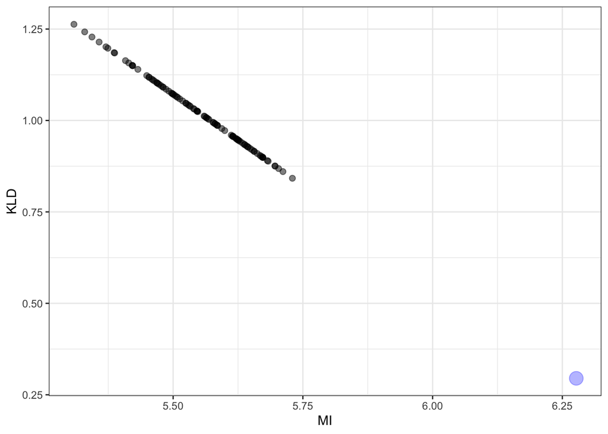

```r
df_mi_english_weighted %>%
  ggplot(aes(x = MI,
             y = KLD)) +
  geom_point(alpha = .5,
             size = 2) +
  geom_point(data = real_english,
             aes(x = MI,
                 y = KLD),
             color = "Blue",
             alpha = .3,
             size = 5) +
  theme_bw()
```

# Dutch Lexicon

First, load wordforms with phonotactic measures, and normalize their probabilities.

```r
df_dutch = read_csv("../data/processed/dutch/reals/dutch_with_mps_5phone_holdout.csv")
df_dutch = df_dutch %>%
  mutate(p = 10 ** heldout_log_prob) %>%
  mutate(wordform = PhonDISC) %>%
  group_by(num_sylls_est) %>%
  mutate(total_p = sum(p)) %>%
  mutate(p_normalized = p / total_p)

## Add #sylls
df_sylls = df_dutch %>%
  select(num_sylls_est, PhonDISC)
```

Next, load the lemmas with their frequency estimates.

```r
df_dutch_lemmas = read_delim("../data/frequency/dutch/lemmas.csv", delim = "\\")
nrow(df_dutch_lemmas)
```

```
## [1] 123926
```

```r
df_dutch_lemmas = df_dutch_lemmas %>%
  mutate(freq_adjusted = Inl + 1) %>%
  group_by(PhonDISC) %>%
  mutate(total_frequency = sum(freq_adjusted),
         relative_frequency = freq_adjusted / total_frequency) %>%
  ungroup()

## Add #sylls
df_dutch_lemmas = df_dutch_lemmas %>%
  left_join(df_sylls, on = PhonDISC) %>%
  drop_na(num_sylls_est)
df_dutch_lemmas$lemma_id = c(1:nrow(df_dutch_lemmas))
```

## Calculate scores for real lexicon

```r
df_dutch_lemmas = df_dutch_lemmas %>%
  mutate(wordform = PhonDISC) %>%
  calculate_MI() %>%
  mutate(kld = pm * log(1/cond_prob))


## Calculate summary MI and KL-D
real_dutch = df_dutch_lemmas %>%
  summarise(KLD = sum(kld),
            MI = sum(mi))

real_dutch
```

```
## # A tibble: 1 × 2
##     KLD    MI
##   <dbl> <dbl>
## 1 0.147  5.98
```

## Calculate scores for artificial lexica

Now, create the baselines and compare them to the real lexicon.

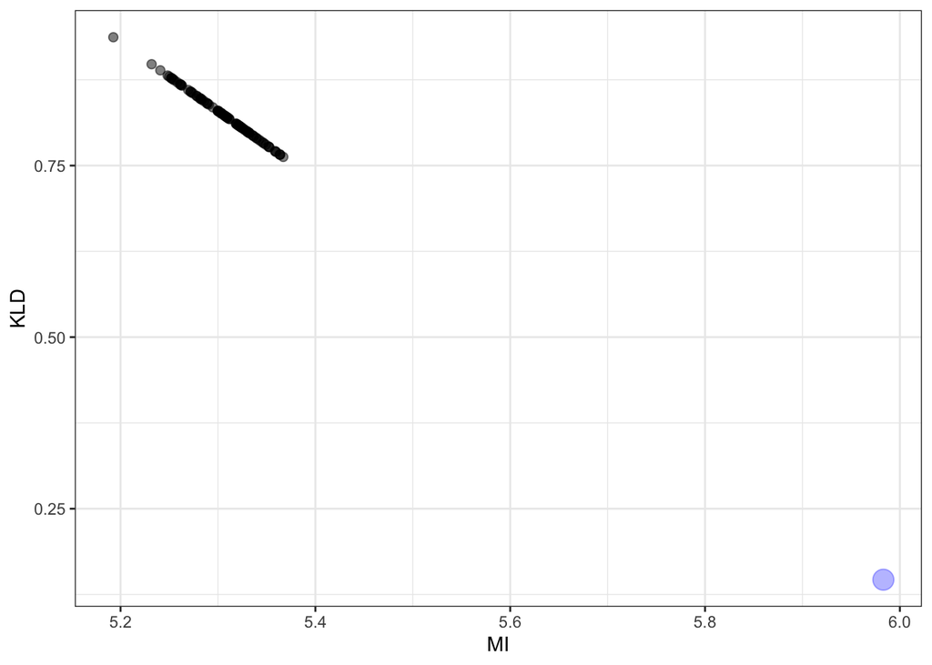

```r
df_mi_dutch = create_baselines_phonotactic_weighting(df_dutch,
                                                df_dutch_lemmas,
                                                N = 100)

df_mi_dutch %>%
  ggplot(aes(x = MI,
             y = KLD)) +
  geom_point(alpha = .5,
             size = 2) +
  geom_point(data = real_dutch,
             aes(x = MI,
                 y = KLD),
             color = "Blue",
             alpha = .3,
             size = 5) +
  theme_bw()
```

# German Lexicon

First, load wordforms with phonotactic measures, and normalize their probabilities.

```r
df_german  = read_csv("../data/processed/german/reals/german_with_mps_5phone_holdout.csv")
df_german = df_german %>%
  mutate(wordform = PhonDISC) %>%
  mutate(p = 10 ** heldout_log_prob) %>%
  group_by(num_sylls_est) %>%
  mutate(total_p = sum(p)) %>%
  mutate(p_normalized = p / total_p)

## Add #sylls
df_sylls = df_german %>%
  select(num_sylls_est, PhonDISC)
```

Next, load the lemmas with their frequency estimates.

```r
df_german_lemmas = read_delim("../data/frequency/german/lemmas.csv", delim = "\\")
nrow(df_german_lemmas)
```

```
## [1] 51728
```

```r
df_german_lemmas = df_german_lemmas %>%
  mutate(freq_adjusted = Mann + 1) %>%
  group_by(PhonDISC) %>%
  mutate(total_frequency = sum(freq_adjusted),
         relative_frequency = freq_adjusted / total_frequency) %>%
  ungroup()

## Add #sylls
df_german_lemmas = df_german_lemmas %>%
  left_join(df_sylls, on = PhonDISC) %>%
  drop_na(num_sylls_est)
df_german_lemmas$lemma_id = c(1:nrow(df_german_lemmas))
```

## Calculate scores for real lexicon

```r
df_german_lemmas = df_german_lemmas %>%
  mutate(wordform = PhonDISC) %>%
  calculate_MI() %>%
  mutate(kld = pm * log(1/cond_prob))


## Calculate summary MI and KL-D
real_german = df_german_lemmas %>%
  summarise(KLD = sum(kld),
            MI = sum(mi))

real_german
```

```
## # A tibble: 1 × 2
##     KLD    MI
##   <dbl> <dbl>
## 1 0.320  6.53
```

## Calculate scores for artificial lexica

Now, create the baselines and compare them to the real lexicon:

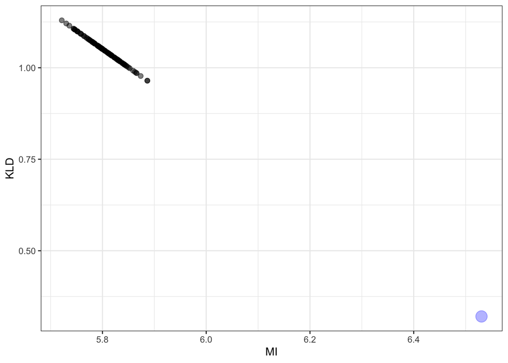

```r
df_mi_german = create_baselines_phonotactic_weighting(df_german,
                                                df_german_lemmas,
                                                N = 100)


df_mi_german %>%
  ggplot(aes(x = MI,
             y = KLD)) +
  geom_point(alpha = .5,
             size = 2) +
  geom_point(data = real_german,
             aes(x = MI,
                 y = KLD),
             color = "Blue",
             alpha = .3,
             size = 5) +
  theme_bw()
```

# French Lexicon

```r
df_french = read_csv("../data/processed/french/reals/french_with_mps_4phone_holdout.csv")
nrow(df_french)
```

```
## [1] 37278
```

```r
df_french = df_french %>%
  # This is important to get the baseline functions to work (references "wordform" column)
  mutate(wordform = `2_phon`) %>%
  mutate(p = 10 ** heldout_log_prob) %>%
  group_by(num_sylls_est) %>%
  mutate(total_p = sum(p)) %>%
  mutate(p_normalized = p / total_p)

## Add #sylls
df_sylls = df_french %>%
  select(num_sylls_est, wordform)
```

Next, load the lemmas with their frequency estimates.

```r
df_french_lemmas = read_csv("../data/processed/french/reals/french_all_reals_4phone.csv")
nrow(df_french_lemmas)
```

```
## [1] 43782
```

```r
sum(df_french_lemmas$`10_freqlivres`)
```

```
## [1] 641975.5
```

```r
df_french_lemmas = df_french_lemmas %>%
  mutate(wordform = `2_phon`) %>%
  ## Multiply by 14.8, b/c measures were divided by 14.8 in Lexique
  mutate(freq_adjusted = `8_freqlemlivres` * 14.8 + 1) %>%
  group_by(wordform) %>%
  mutate(total_frequency = sum(freq_adjusted),
         relative_frequency = freq_adjusted / total_frequency) %>%
  ungroup()
nrow(df_french_lemmas)
```

```
## [1] 43782
```

```r
## Add #sylls
df_french_lemmas = df_french_lemmas %>%
  left_join(df_sylls, on = wordform) %>%
  drop_na(num_sylls_est)
df_french_lemmas$lemma_id = c(1:nrow(df_french_lemmas))
```

## Calculate scores for real lexicon

```r
df_french_lemmas = df_french_lemmas %>%
  calculate_MI() %>%
  mutate(kld = pm * log(1/cond_prob))

## Calculate summary MI and KL-D
real_french = df_french_lemmas %>%
  summarise(KLD = sum(kld),
            MI = sum(mi))

real_french
```

```
## # A tibble: 1 × 2
##     KLD    MI
##   <dbl> <dbl>
## 1 0.279  6.48
```

## Calculate scores for artificial lexica

Now, create the baselines and compare them to the real lexicon.

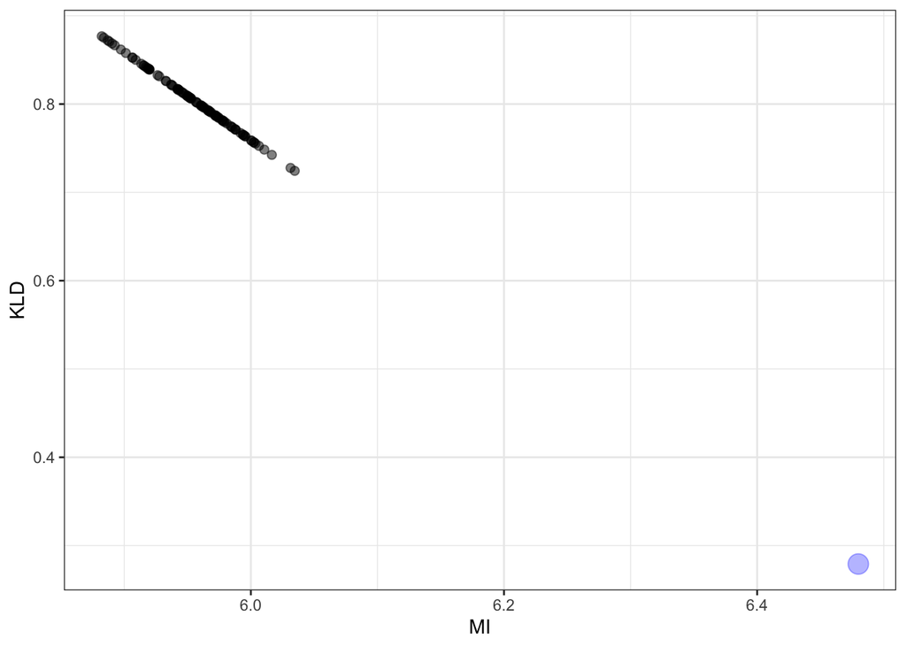

```r
df_mi_french = create_baselines_phonotactic_weighting(df_french,
                                                df_french_lemmas,
                                                N = 100)

df_mi_french %>%
  ggplot(aes(x = MI,
             y = KLD)) +
  geom_point(alpha = .5,
             size = 2) +
  geom_point(data = real_french,
             aes(x = MI,
                 y = KLD),
             color = "Blue",
             alpha = .3,
             size = 5) +
  theme_bw()
```

# Mandarin Lexicon

First, load wordforms with phonotactic measures, and normalize their probabilities.

```r
df_mandarin = read_csv("../data/processed/mandarin_cld/reals/mandarin_cld_with_mps_4phone_holdout.csv")
nrow(df_mandarin)
```

```
## [1] 41009
```

```r
df_mandarin = df_mandarin %>%
  # This is important to get the baseline functions to work (references "wordform" column)
  mutate(wordform = phonetic_remapped) %>%
  mutate(p = 10 ** heldout_log_prob) %>%
  group_by(num_sylls_est) %>%
  mutate(total_p = sum(p)) %>%
  mutate(p_normalized = p / total_p)

## Add #sylls
df_sylls = df_mandarin %>%
  select(num_sylls_est, wordform)
```

Next, load the lemmas with their frequency estimates.

```r
df_mandarin_lemmas = read_csv("../data/processed/mandarin_cld/reals/mandarin_cld_all_reals_4phone.csv")
nrow(df_mandarin_lemmas)
```

```
## [1] 45552
```

```r
sum(df_mandarin_lemmas$FrequencyRaw)
```

```
## [1] 120114912
```

```r
df_mandarin_lemmas = df_mandarin_lemmas %>%
  mutate(wordform = phonetic_remapped) %>%
  mutate(freq_adjusted = FrequencyRaw +1) %>%
  group_by(phonetic_remapped) %>%
  mutate(total_frequency = sum(freq_adjusted),
         relative_frequency = freq_adjusted / total_frequency) %>%
  ungroup()
nrow(df_mandarin_lemmas)
```

```
## [1] 45552
```

```r
## Add #sylls
df_mandarin_lemmas = df_mandarin_lemmas %>%
  left_join(df_sylls, on = wordform) %>%
  drop_na(num_sylls_est)
df_mandarin_lemmas$lemma_id = c(1:nrow(df_mandarin_lemmas))
```

## Calculate scores for real lexicon

```r
df_mandarin_lemmas = df_mandarin_lemmas %>%
  calculate_MI() %>%
  mutate(kld = pm * log(1/cond_prob))

## Calculate summary MI and KL-D
real_mandarin = df_mandarin_lemmas %>%
  summarise(KLD = sum(kld),
            MI = sum(mi))

real_mandarin
```

```
## # A tibble: 1 × 2
##     KLD    MI
##   <dbl> <dbl>
## 1 0.142  6.79
```

## Calculate scores for artificial lexica

Now, create an artificial lexicon:

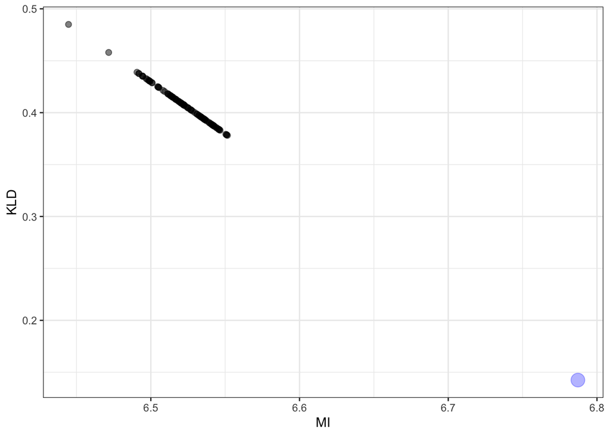

```r
df_mi_mandarin = create_baselines_phonotactic_weighting(df_mandarin,
                                                df_mandarin_lemmas,
                                                N = 100)

df_mi_mandarin %>%
  ggplot(aes(x = MI,
             y = KLD)) +
  geom_point(alpha = .5,
             size = 2) +
  geom_point(data = real_mandarin,
             aes(x = MI,
                 y = KLD),
             color = "Blue",
             alpha = .3,
             size = 5) +
  theme_bw()
```

# Combine all together

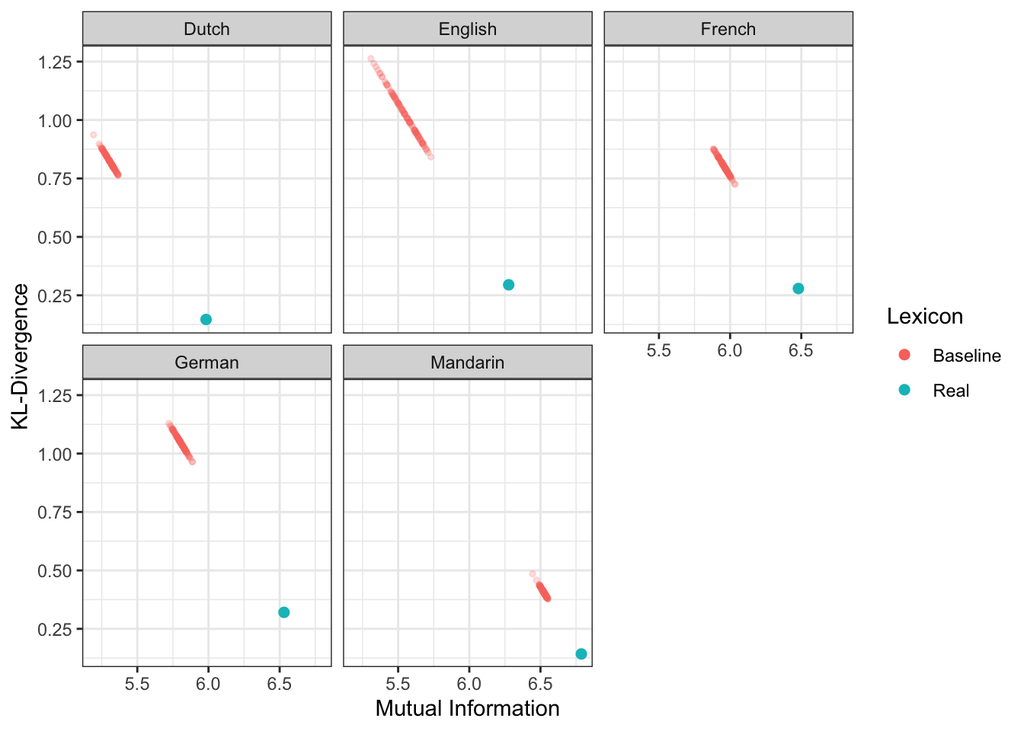

```r
real_english = real_english %>%
  mutate(Lexicon = "Real",
         Language = "English")
real_german = real_german %>%
  mutate(Lexicon = "Real",
         Language = "German")
real_dutch = real_dutch %>%
  mutate(Lexicon = "Real",
         Language = "Dutch")
real_french = real_french %>%
  mutate(Lexicon = "Real",
         Language = "French")
real_mandarin = real_mandarin %>%
  mutate(Lexicon = "Real",
         Language = "Mandarin")

df_mi_english_weighted = df_mi_english_weighted %>%
  mutate(Language = "English",
         Lexicon = "Baseline")
df_mi_dutch = df_mi_dutch %>%
  mutate(Language = "Dutch",
         Lexicon = "Baseline")
df_mi_french = df_mi_french %>%
  mutate(Language = "French",
         Lexicon = "Baseline")
df_mi_german = df_mi_german %>%
  mutate(Language = "German",
         Lexicon = "Baseline")
df_mi_mandarin = df_mi_mandarin %>%
  mutate(Language = "Mandarin",
         Lexicon = "Baseline")

## Combine together
df_mi_all = df_mi_english_weighted %>%
  bind_rows(df_mi_dutch) %>%
  bind_rows(df_mi_french) %>%
  bind_rows(df_mi_german) %>%
  bind_rows(df_mi_mandarin) %>%
  bind_rows(real_english) %>%
  bind_rows(real_dutch) %>%
  bind_rows(real_french) %>%
  bind_rows(real_german) %>%
  bind_rows(real_mandarin)


df_mi_real = df_mi_all %>%
  filter(Lexicon == "Real")

df_mi_art = df_mi_all %>%
  filter(Lexicon == "Baseline")

df_mi_all %>%
  ggplot(aes(x = MI,
             y = KLD,
             color = Lexicon)) +
  geom_point(alpha = .2,
             size = 1) +
  theme_bw() +
  geom_point(data = df_mi_real,
             aes(x = MI,
                 y = KLD),
             size = 2) +
  labs(x = "Mutual Information",
       y = "KL-Divergence") +
  facet_wrap(~Language)
```

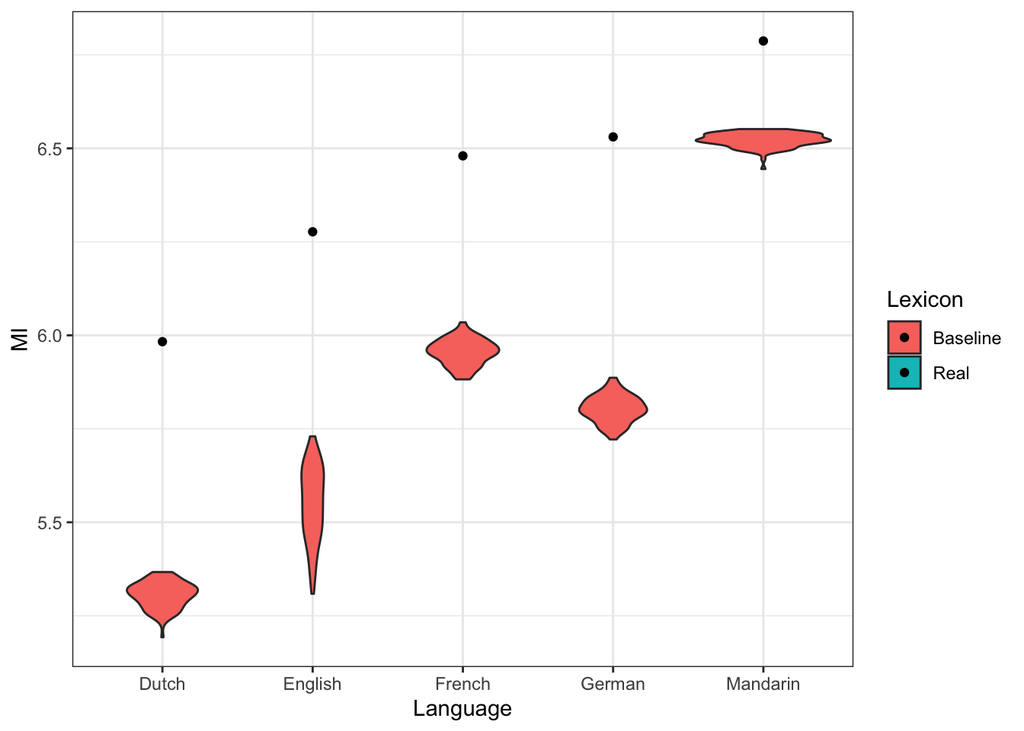

```r
ggsave("../Figures/s4_scatter.png", dpi = 300)
df_mi_art %>%
  ggplot(aes(x = Language,
             y = MI,
             fill = Lexicon)) +
  geom_violin() +
  geom_point(data = df_mi_real,
             aes(x = Language,
                 y = MI)) +
  theme_bw()
```

```r
ggsave("../Figures/supp_mi_violin.png", dpi = 300)
```